# Texas Equity Metrics

Dashiell Young-Saver, Jared Knowles

Jun 30, 2018

# Creating Equity Metrics

*Using Texas state testing data files* *Programmed in R*

## Getting Started

To complete this tutorial, the user will need R, RStudio, and the following R packages installed on his/her machine:

- `tidyverse`: For convenient data and output manipulation
- `ggplot2`: For graphics
- `broom`: For tidying regression output
- `FSA`: To create comparative summary tables

To install packages, such as `ggplot2`, run the following command in the R console:

`install.packages('ggplot2')`

In addition, this guide will draw from OpenSDP-written functions defined in the `functions.R` document, which is located in the `R` folder of this guide’s GitHub repository. Please make sure to have downloaded the entire GitHub repository to run this code.

### Objective

In this guide, you will use data visualization and descriptive statistics to investigate equity in student testing outcomes along lines of race, income, gender, learning differences, English proficiency, and migrant status.

### Using this Guide

This guide utilizes mock data from Texas’s standardized exams (STAAR test, grades 3-8). Therefore, Texas districts can use this code to directly analyze the testing data files they have received from the Texas Education Agency. However, the code can be adapted to any other state or district context in which student testing outcomes are analyzed.

Once you have identified analyses that you want to try to replicate or modify, click the “Download” buttons to download R code and sample data. You can make changes to the charts using the code and sample data, or modify the code to work with your own data. If you are familiar with GitHub, you can click “Go to Repository” and clone the entire repository to your own computer.

Go to the Participate page to read about more ways to engage with the OpenSDP community or reach out for assistance in adapting this code for your specific context.

### About the Data

The data used in this guide was synthetically generated, and it was formatted to match the Texas Education Agency’s state test file formats (Texas’s file formats can be found here: https://tea.texas.gov/student.assessment/datafileformats). The data has one record per student. Out of the hundreds of features reported for each student by the Texas Education Agency, we used (and retained) the following features in our analysis: student grade level (3-8), school code, student ID, gender, race-ethnicity, economic disadvantage level, Limited English Proficiency level, and scale scores in reading, math, and writing (for the STAAR state test). We also used indicators of whether or not the student attended a Title 1 school, was a migrant, and was enrolled in special education. Here is a key of the features and their variable names in our simulated data set:

| Feature name | Feature Description |
| --- | --- |
| `grade_level` | Grade level of exam student took (3-8) |
| `school_code` | School ID number |
| `sid` | Student ID number |
| `male` | Student gender |
| `race_ethnicity` | Student race/ethnicity |
| `eco_dis` | Student level of economic disadvantage |
| `title_1` | Indicator if student attends Title 1 school |
| `migrant` | Indicator if student is a migrant |
| `lep` | Level of Limited English Proficiency |
| `iep` | Indicator if student enrolled in special education |
| `rdg_ss` | Scale score for reading exam |
| `math_ss` | Scale score for math exam |
| `wrtg_ss` | Scale score for writing exam |
| `composition` | Score on writing composition exam |

The original Texas Education Agency data files have hundreds of features attached to each student record. Coding our analyses with all of these features could get unwieldy, so the best practice is to select the key features we will need for our analyses. If you would like to directly use your own data with the code from this guide, it is best to delete unnecessary features and change the headers to the feature names we chose (above). A more detailed data definition guide can be found in the `man` folder in the GitHub repository.

Although not required, it is useful to compile a small table of the standard deviations of the scores on the exams statewide, broken down by grade and subject area. This will allow us to compute more standardized measures of gaps in the following code. Here is an example of the expected table format, using standard deviations by grade and tested area from the 2014 Texas state STAAR exams:

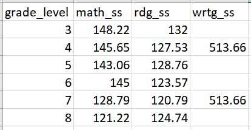

This standard deviation table is used in the code, specifically imported into the `sd_table` variable.

#### Loading the OpenSDP Data set and R Packages

This guide takes advantage of the OpenSDP synthetic data set and several key R packages. The first chunk of code below loads the R packages (make sure to install first!), and the second chunk loads the data set and provides us with variable labels. You can change the variable labels depending on the variables in your data set.

```r
#Packages
library(tidyverse) # main suite of R packages to ease data analysis
library(ggplot2) # to plot
library(FSA) # functions for useful summary tables
# Read in some R functions that are convenience wrappers
source("../R/functions.R")
```

```r
# // Step 1: Read in csv file of our dataset, naming it "texas_data"
texas_data <- read.csv("../data/synth_texas.csv")

# // Step 2 (Optional): Read in file containing state-wide standard deviations for standardized tests
sd_table <- read.csv("../data/sd_table.csv")

# // Step 3: Create a vector of labels for feature names in our dataset
#These labels will appear in visualizations and tables
labels <- c("Grade","School ID","Student ID","Gender", "Race-Ethnicity",
            "Econ Disadvantage Status","Title 1 Status","Migrancy Status",
            "LEP Status","Spec Ed Enrolled","Reading Score",
            "Math Score","Writing Score","Writing Comp Score")


#Pairs labels with feature names from file
names(labels) <- c("grade_level","school_code","sid","male","race_ethnicity",
                   "eco_dis","title_1","migrant",
                   "lep","iep","rdg_ss",
                   "math_ss","wrtg_ss","composition")

## Set state proficiency levels
prof_lev <- expand.grid(grade = 3:8, subject = c("math_ss", "rdg_ss"),
               prof_level = c("approaching", "meets", "masters"))

prof_lev$score <- c(1360, 1467, 1500, 1536, 1575, 1595,
                  1345, 1434, 1470, 1517, 1567, 1587,
                  1486, 1589, 1625, 1653, 1688, 1700,
                  1468, 1550, 1582, 1629, 1674, 1700,
                  1596, 1670, 1724, 1772, 1798, 1854,
                  1555, 1633, 1667, 1718, 1753, 1783)
```

Note that the above code chunk also stores proficiency levels set by the state of Texas, which include score cut-offs for “approaching,” “meets,” and “masters” on its state tests. Including proficiency levels will be helpful for the visualizations included below, in order to give the viewer a sense of scale and a sense of score quality. The user can adjust these proficiency levels, depending on context.

### About the Analyses

In various contexts, students of different identity markers (race, class, gender, English Language Learner status, etc.) may have systematically differing educational outcomes. These gaps often present themselves in standardized testing data, at the national, state, and local levels. The following analyses will assist your organization in seeing where gaps exist and how wide they are, in order to inform the conversation about why the gaps exist and what to do about them.

### Giving Feedback on this Guide

This guide is an open-source document hosted on GitHub and generated using R Markdown. We welcome feedback, corrections, additions, and updates. Please visit the OpenSDP equity metrics repository to read our contributor guidelines.

## Analyses

We will now walk through a series of four analysis in this guide. The first will be a basic exploration of the performance gaps by subgroups on the assessments. The next will look at how the gaps vary across schools. The third will model a targeting exercise to identify schools for possible intervention or further investigation. The final analysis will use regression modeling to look at the magnitude of the largest gap(s) in the district while controlling for other factors.

### Exploratory Analysis

**Purpose:** Descriptive statistics give your agency a quick snapshot of current achievement gaps among students, identifying areas for further investigation and analysis.

**Required Analysis File Variables:**

- `grade_level`
- `school_code`
- `male`
- `race_ethnicity`
- `eco_dis`
- `title_1`
- `migrant`
- `lep`
- `iep`
- `rdg_ss`
- `math_ss`
- `wrtg_ss`
- `composition`

**Ask Yourself**

- How do different study sub-populations in your organization perform on standardized tests?
- Which differences do you want to explore further?

**Analytic Technique:** Identify major achievement gaps within the student population. To achieve this, we use the SDP function `gap.test`, which is defined in the repository’s `R` folder. You can review the source code of this function there. For now, here is the usage information:

`gap.test`: Visualizes and quantifies gaps in student performance across demographic markers.

Output: A `data.frame` table of the top `n` gaps, as measured by effect size, as well as the demographic and test information for each gap. Function also prints comparative visuals of top gaps.

Inputs:

`gap.test(df, grade, outcome, features, n = 3, sds = NULL, comp = FALSE, cut = NULL, med = FALSE, outlbl = NULL)`

- df = data set, should be wide format, one row per student, and have column for grade level (class: data frame)
- grade = name of tested grade column in data set (class: character)
- outcome = name of outcome variable (usually test scores) in data set (class: character)
- features = vector of features in data set where testing for gaps (class: character)
- n (optional) = Number of largest gaps the function outputs (class: integer, default: 3)
- sds (optional) = dataframe containing the state-wide standard deviations for all outcomes/exams (class: data frame, default: NULL)
- comp (optional) = Indicator to output additional comparative gap graphics (class: boolean, default: FALSE)
- cut (optional) = Minimum number of students for level in a gap (class: integer, default: NULL)
- med (optional) = Indicator if would like function to also output standardized difference of medians, in addition to effect size (class: boolean, default: FALSE)
- outlbl (optional) = label for measured outcome, to print on graphs (class: character, default: NULL)

More detailed usage information can be found in the `R` folder in the GitHub repository. We use the function here to find the top 3 gaps in math scores, in terms of effect size, between students of different economic disadvantage levels, races, genders, Special Education statuses, and LEP statuses. We check among all grades in the dataset: 3-8. The number of top gaps shown can be changed based on user inputs, as well as the gap categories and subject areas measured.

```r
#Use 'gap.test' function to explore most major gaps in student population
gap.table <- gap.test(df = texas_data,
                    grade = "grade_level",
                    outcome = "math_ss",
                    features = c('eco_dis','lep','iep','race_ethnicity','male'),
                    sds = sd_table,
                    n = 3,
                    cut = 120,
                    outlbl = "math score gap")
```

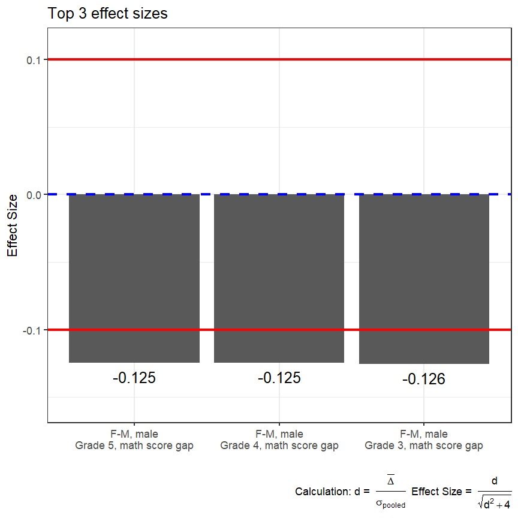

The `gap.test` output shows us that the top 3 gaps, in terms of effect size, are for 3rd, 4th, and 5th grade math scores between gender groups. The effect sizes are negative, and the labeling on the graph shows us the effect size was calculated with the average score for male “M” students subtracted from the average score for female “F” students. Thus, on average, the male students scored higher than female students. In our data set, these gaps were wider than any other gap based in racial differences, socioeconomic differences, differences in English proficiency status, or differences in special education status.

The function also outputs a table with each effect size, mean difference (to show the gap on the scale of the test), and demographic information of the gap (groups affected, grade level, test subject). We have stored this as `gap.table`. If wanted, the user could set the inputs (see usage information above) of the function such that it outputs additional graphics, comparing gaps within each data set feature. Here, we output one graphic for simplicity.

Measuring the gaps in terms of effect size allows us to compare gaps across grade levels and subject areas, as effect size standardizes the gap by taking into account the pooled standard deviation of the tested groups on the tests they took. A good rule of thumb is that an effect size greater in magnitude than 0.1 usually translates to meaningful differences in student learning. Hence, horizontal lines are labeled on the graph at 0.1 and -0.1. Gaps that surpass these thresholds should be looked at more thoroughly. The gender gaps in our data surpass this threshold and are similar across grade levels. For simplicity, this report will focus on one grade level, but the following analyses can be done across grade levels.

One technical note: Sometimes the distributions of test scores can be skewed, making the median a more advantageous measure of central tendency (since it is less sensitive to outliers and skew). In these cases, set the `gap.test` function’s `med` parameter to `TRUE` to output a plot that shows the top 3 gaps as measured by the standardized median difference.

Since our largest effect size gap was the grade 3 gender gap on the standardized math test, we will explore that gap further. For demonstration purposes, we will focus on just that one gap here. However, the next chunk of code will determine which gap(s) will be explored in the rest of our analyses. The user can explore multiple gaps at once by setting the following variables to include multiple gaps from `gap.table`. This is shown in commented out code in the middle of the chunk.

```r
# // Option 1: Choose to analyze just the largest gap
gaps <- gap.table[1,]
rownames(gaps) <- NULL

# // Option 2: Choose to analyze the top 'k' gaps
#gaps <- gap.table[1:k,]
#rownames(gaps) <- NULL

# // Option 3: Choose to analyze the 'kth' through 'jth' gaps
#gaps <- gap.table[k:j,]
#rownames(gaps) <- NULL

# // Option 4: Choose to analyze the 'kth' gap only
#gaps <- gap.table[k,]
#rownames(gaps) <- NULL

# // Step 2: Set the number of gaps you'll be analyzing
n.gaps <- 1
```

**Analytic Technique:** Calculate the summary statistics for exam performance, for all students at the grade level(s) in which gaps are measured. This will give us a few points of reference. Here, we look at the distribution of scores on the 3rd grade math test.

```r
#Prints summary statistics for each gap's grade level
#Loop over gap number in our table of gaps
for(i in 1:n.gaps){

  #Save grade and subject tested information
  grade <- gaps[i,"grade_level"]
  subject <- gaps[i,"outcome"]

  data = texas_data[texas_data$grade_level == grade,] #Isolates grade level
  print(paste("Grade level:",grade,", Outcome:",labels[subject]))
  a <- summary(data[,subject]) #Summary stats table for grade and test
  print(a) #Print summary table

}#End loop over gap number
```

```
[1] "Grade level: 3 , Outcome: Math Score"
   Min. 1st Qu.  Median    Mean 3rd Qu.    Max.
   1071    1374    1479    1483    1598    1830
```

One particularly useful output in this summary is that we see the minimum and maximum scores in our data set, which gives us a rough sense of the bounds for scores on this type of exam. It is tough to get a sense of the shape of the distribution from summary statistics alone, so we will turn to visualization.

**Analytic Technique:** Create visualizations of the data, to provide a more developed sense of the distributions behind these summary statistics. Specifically, here we use box plots and histograms

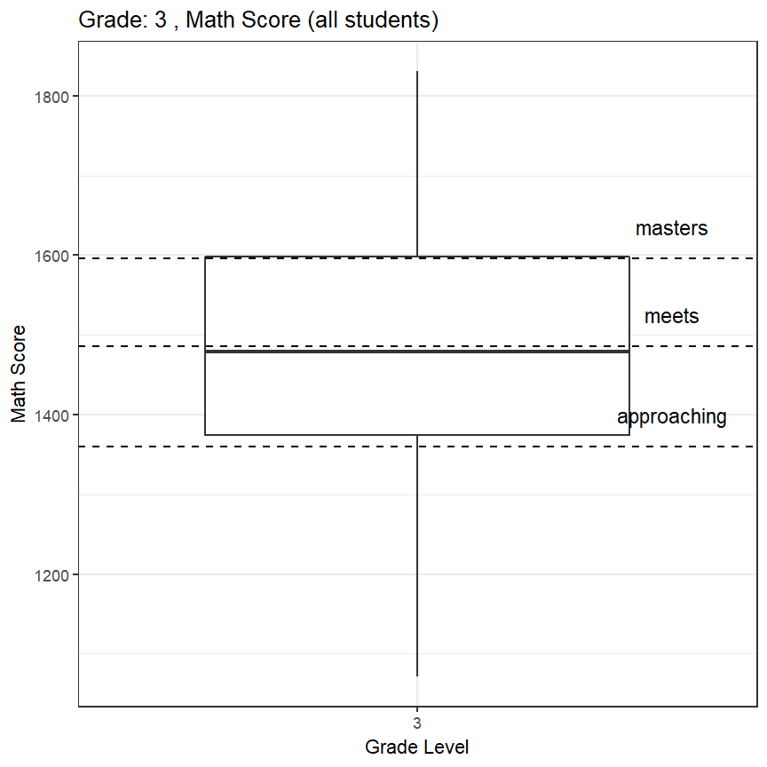

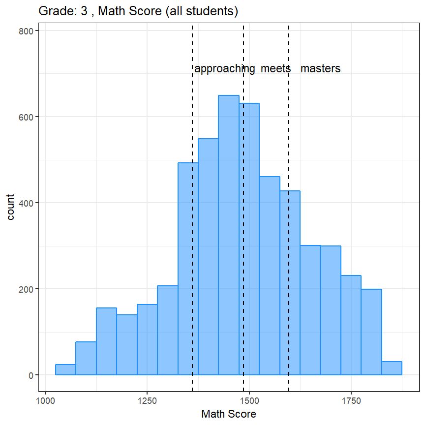

```r
# // Visualizations: Box plots and Histograms
#Loop over gap number in our table of gaps
for(i in 1:n.gaps){

  #Save grade and subject tested information
  grade <- gaps[i,"grade_level"]
  subject <- gaps[i,"outcome"]

  data = texas_data[texas_data$grade_level == grade,] #Isolates 5th and 8th graders

    #Set variables and parameters for our boxplot
    p <- ggplot(data, aes(x=as.factor(grade_level), y=data[,subject])) +
          geom_boxplot() +
          ggtitle(paste("Grade:",grade,",",labels[subject], "(all students)")) +
          scale_y_continuous(name=labels[subject]) +
          scale_x_discrete(name="Grade Level")

    p <- add_ref_levels(plot = p, prof_levels = prof_lev, direction = "horizontal",
                         grade = grade, subject = subject) + theme_bw()
        print(p) #Print boxpolot

    #Set variables and parameters for our histogram
    p <- ggplot(data, aes(x=data[,subject])) +
          ggtitle(paste("Grade:",grade,",",labels[subject], "(all students)"))+
          geom_histogram(alpha = 0.5, binwidth = 50, fill = "dodgerblue",
                         color = "dodgerblue") +
          scale_x_continuous(name=paste(labels[subject]))
    # This function adds reference lines for proficiency levels to a plot of test
    # scores, it uses the defined proficiency level object prof_lev, that we input
    # above to augment the plot with proficiency levels
    p <- add_ref_levels(plot = p, prof_levels = prof_lev, direction = "vertical",
                         grade = grade, subject = subject) +
      theme_bw()


    print(p) #Print histogram


}#End loop over gap number
```

We see left skew in the distribution of scores, as evidenced by the box plot and (more clearly) evidenced by the histogram. With skew present, it often makes sense to use the median as a measure of central tendency, since it is less susceptible to skew than the mean. We will keep this in mind during our forthcoming analyses. In addition, it is notable that the median of scores is very close to the the “meets standard” benchmark, while the third quartile of scores is very close the mastery benchmark level. This means that about half of all students meet the standard and a quarter of all students show mastery level understanding on the exam.

**Analytic Technique:** Compare descriptive statistics among the different student demographic populations described in our gap. Now that we have some measures for the performance on exams among all of our students, we can create those same measures for male and female students. Then, we can compare them.

```r
# // Comparisons: Generating summary stats for demographics in gaps
#Loop over gap number in our table of gaps
for(i in 1:n.gaps){

  #Save grade, subject tested, and demographic information
  grade <- gaps[i,"grade_level"]
  subject <- gaps[i,"outcome"]
  dem <- gaps[i,"feature"]
  lvl1 <- gaps[i,"level_1"]
  lvl2 <- gaps[i,"level_2"]

  #Isolate data for grade and gap demographics
  data = texas_data[texas_data$grade_level == grade,] #Isolates grade level
  data = data[data[,dem] == lvl1 | data[,dem] == lvl2, ]#Isolates demographic groups

  #Print subject and grade level
  print(paste("Grade:",grade,",",labels[subject]))

  a <- Summarize(data[, subject] ~ data[, dem]) #Makes comparison table
      colnames(a)[1] <- labels[dem] #Labels comparison table
      print(a) #Prints comparison table

} #End loop over gap number
```

```
[1] "Grade: 3 , Math Score"
  Gender    n     mean       sd      min      Q1   median       Q3      max
1      F 2394 1461.187 167.0296 1071.238 1354.22 1456.440 1577.068 1797.038
2      M 2645 1503.434 166.4933 1104.596 1397.16 1500.294 1616.803 1830.397
```

We can see that we have more male than female students in our data. In addition, each statistic (Q1, median, mean, Q3, min, max) is shifted up about 40 points for males, compared to females. This suggests that the distributions share a shape, but are centered at different scale scores. We will explore this hypothesis directly by looking at shapes through visualization.

**Analytic Technique:** Visualize the comparisons, to give us a sense of scale and shape in these gaps. To do so, we will use both box plots broken down by gender and a stacked histogram broken down by gender.

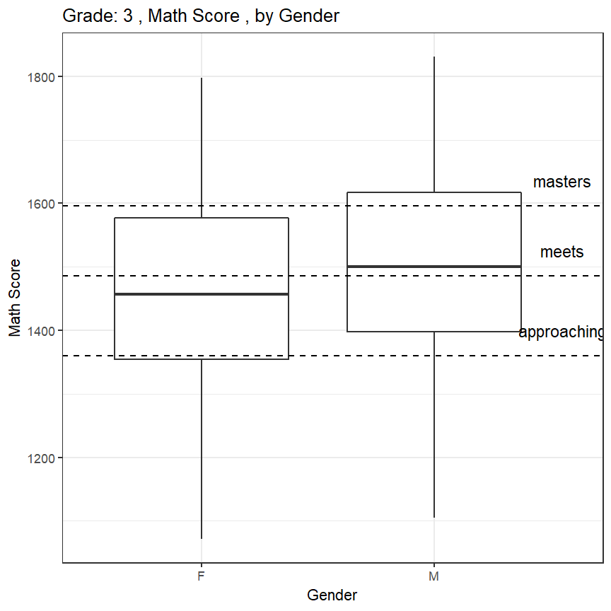

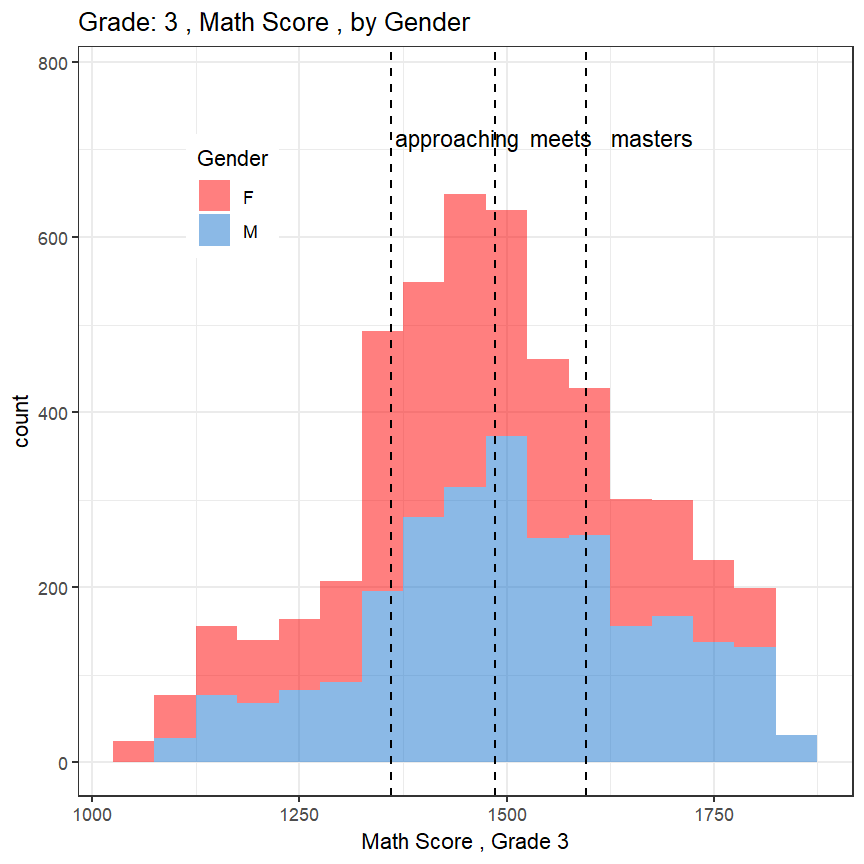

```r
# // Step 1: Initialize a set of distinguishable colors for graphics
colors <- c("red","dodgerblue3","green","coral","violet","burlywood2","grey68")

#Loop over gap number in our table of gaps
for(i in 1:n.gaps){

  #Save grade, subject tested, and demographic information
  grade <- gaps[i,"grade_level"]
  subject <- gaps[i,"outcome"]
  dem <- gaps[i,"feature"]
  lvl1 <- gaps[i,"level_1"]
  lvl2 <- gaps[i,"level_2"]

  data = texas_data[texas_data$grade_level == grade,] #Isolates grade level
  data = data[data[,dem] == lvl1 | data[,dem] == lvl2, ]#Isolates demographic groups

  #Set variables and parameters for our boxplot
  bp <- ggplot(data, aes(x=as.factor(data[,dem]), y=data[,subject])) +
        geom_boxplot() +
        ggtitle(paste("Grade:",grade,",", labels[subject],", by",labels[dem])) +
        scale_y_continuous(name=labels[subject]) +
        scale_x_discrete(name=labels[dem]) +
    theme_bw()
  # print(bp) #Print box plot

    bp <- add_ref_levels(plot = bp, prof_levels = prof_lev, direction = "horizontal",
                         grade = grade, subject = subject)
    print(bp)

  #Set variables and parameters for our histogram
  h <- ggplot(data, aes(x=data[,subject], fill = as.factor(data[,dem]))) +
        ggtitle(paste("Grade:",grade,",", labels[subject],", by",labels[dem]))+
        geom_histogram(alpha = 0.5, binwidth = 50) +
        scale_fill_manual(name=labels[dem],
                          values=colors[1:length(levels(as.factor(data[,dem])))])+
        scale_x_continuous(name=paste(labels[subject], ", Grade", grade))
  # print(h) #Print histogram

  h <- add_ref_levels(plot = h, prof_levels = prof_lev, direction = "vertical",
                         grade = grade, subject = subject) + theme_bw() +
    theme(legend.position = c(0.2, 0.8))
    print(h)


} #End loop over gap number
```

As we predicted, the distributions have similar shapes, with the male distribution shifted to higher scores than the female distribution. When broken down by gender group, the distributions maintain a left skew, which provides even more support for using the median as a measure of central tendency in the following analyses.

Among all students taking the exam, the median score was very close to the “meets standard” benchmark score and the third quartile was very close to the mastery benchmark. However, the box plot graphic above illustrates that for female students, the median of scores falls below the “meets” benchmark, and the third quartile falls below the mastery benchmark. Therefore, fewer than half of female students met the standard on the exam and fewer than a quarter demonstrated mastery.

By contrast, the median and third quartile for male scores outperform the “meets” and “masters” benchmarks respectively. Greater than half of male students met the standard on the exam and more than a quarter demonstrated mastery.

**Analytic Technique:** Explore gap within levels of another data feature. Often, it can be helpful to look at the intersections of the demographic data we pulled. In particular, exploring possible gaps among combinations of race, socioeconomic status, gender, and student label status (LEP, Spec Ed, Migrant, etc.) can elucidate further achievement gaps in the data. Here, we will explore the intersection of socioeconomic status (measured by economic disadvantage) and the gender gap in math, by measuring the gender gap within each level of socioeconomic status in our data. For example, in this context, the gender gap may be heightened among economically advantaged students but may not be present among economically disadvantaged students. Such a distinction could influence target populations for possible interventions.

The user can change the comparison from socioeconomic status to another factor by manipulating the `group.by` variable.

For reference, Texas defines socioeconomic or “economic disadvantage” levels in its data by the following convention:

| Economic Disadvantage Level | Description |
| --- | --- |
| 1 | Eligible for free meals under the National School Lunch and Child Nutrition Program |
| 2 | Eligible for reduced-price meals under the National School Lunch and Child Nutrition Program |
| 9 | Other economic disadvantage |
| 0 | Not identified as economically disadvantaged |

We perform this through descriptive statistics and data visuals:

```r
# // Analysis 1: Comparing within groups--Socioeconomic gaps within our chosen features
# // Descriptive Statistics
#Set the feature you would like to compare within
group.by <- "eco_dis"

#Loop over gap number in our table of gaps
for(i in 1:n.gaps){

  #Save grade, subject tested, and demographic information
  grade <- gaps[i,"grade_level"]
  subject <- gaps[i,"outcome"]
  dem <- gaps[i,"feature"]
  lvl1 <- gaps[i,"level_1"]
  lvl2 <- gaps[i,"level_2"]

  data = texas_data[texas_data$grade_level == grade,] #Isolates grade level
  data = data[data[,dem] == lvl1 | data[,dem] == lvl2, ]#Isolates demographic groups
  res <- levels(as.factor(data[,group.by])) #Different levels of 'group.by' to explore

  print(paste("Grade:",grade,",",labels[subject])) #Print subject and grade level

  #Loop over group.by levels
  for(re in res){

    #Isolates observations from particular group in group.by
    data.res <- data[data[,group.by]==re,]

    #Makes gap comparison table for particular group
    a<-Summarize(data.res[,subject] ~ data.res[,dem]) #Makes comparison table
    colnames(a)[1] <- labels[dem]
    print(paste(labels[group.by],": ",re))
    print(a) #Prints comparison table

  } #End loop over group.by levels

} #End loop over gap number
```

```
[1] "Grade: 3 , Math Score"
[1] "Econ Disadvantage Status :  0"
  Gender    n     mean       sd      min       Q1   median       Q3      max
1      F 1468 1461.336 170.2181 1071.238 1354.220 1456.440 1583.445 1797.038
2      M 1550 1503.427 169.1258 1104.596 1391.985 1500.294 1623.414 1830.397
[1] "Econ Disadvantage Status :  1"
  Gender   n     mean       sd      min       Q1   median       Q3      max
1      F 603 1460.617 167.2278 1071.238 1348.932 1456.440 1577.068 1797.038
2      M 714 1500.904 160.8026 1104.596 1402.249 1496.734 1598.316 1830.397
[1] "Econ Disadvantage Status :  2"
  Gender   n     mean       sd      min       Q1   median       Q3      max
1      F 197 1470.587 151.4157 1071.238 1378.629 1456.440 1564.958 1797.038
2      M 224 1509.459 167.1570 1104.596 1400.977 1496.734 1632.050 1830.397
[1] "Econ Disadvantage Status :  9"
  Gender   n     mean       sd      min       Q1   median       Q3      max
1      F 126 1447.485 151.9727 1071.238 1344.962 1454.725 1553.618 1764.916
2      M 157 1506.411 166.0911 1104.596 1383.911 1511.660 1623.414 1830.397
```

The summary tables show that the medians are shifted upwards by about 40 points among each socioeconomic group. This would suggest that the inequities have about the same magnitude within each socioeconomic level.

However, measures of central tendency are not the only metrics an analyst can use to compare inequities. The shapes of these distributions may differ between socioeconomic levels. For example, we may notice more right skew among male students who receive free lunch. This could reveal gender inequities among higher-performing students in the free lunch category, which may be unique to that socioeconomic level. In addition, spread could differ between socioeconomic levels.

It can be difficult to judge shape from summary tables.We will make these comparisons through histogram and box plot visualizations.

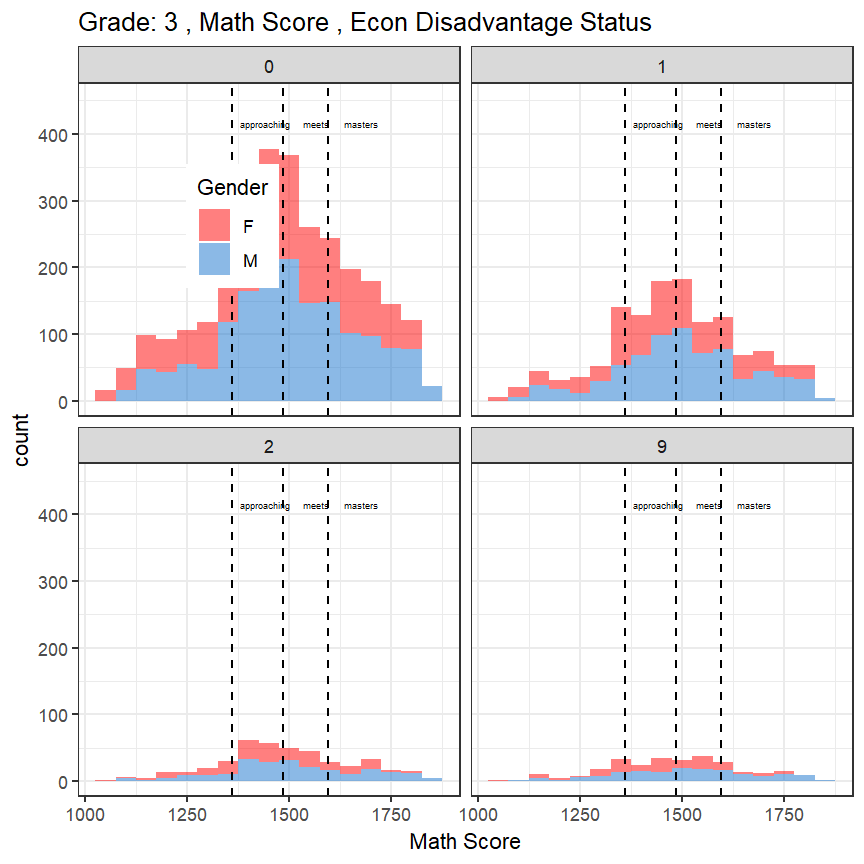

```r
# // Analysis 2: Comparing within groups--Socioeconomic gaps within our chosen features
# // Histograms

#Loop over gap number in our table of gaps
for(i in 1:n.gaps){

  #Save grade, subject tested, and demographic information
  grade <- gaps[i,"grade_level"]
  subject <- gaps[i,"outcome"]
  dem <- gaps[i,"feature"]
  lvl1 <- gaps[i,"level_1"]
  lvl2 <- gaps[i,"level_2"]

  data = texas_data[texas_data$grade_level == grade,] #Isolates grade level
  data = data[data[,dem] == lvl1 | data[,dem] == lvl2, ]#Isolates demographic groups
  res <- levels(as.factor(data[,group.by])) #Different levels of 'group.by' to explore

   # Facet by group by
   h <- ggplot(data, aes(x=data[,subject],
                              fill = as.factor(data[,dem]))) +
              ggtitle(paste("Grade:",grade,",",
                            labels[subject],",",labels[group.by])) +
              geom_histogram(alpha = 0.5, binwidth = 50) +
              scale_fill_manual(name=labels[dem],
              values=colors[1:length(levels(as.factor(data[,dem])))]) +
              scale_x_continuous(name=paste(labels[subject]))  +
     facet_wrap(group.by)

    # Add reference levels
    h <- add_ref_levels(plot = h, prof_levels = prof_lev, direction = "vertical",
                         grade = grade, subject = subject) +
      theme_bw() + theme(legend.position = c(0.2, 0.8))


    print(h) #Print histogram

}# End loop over gap number
```

Histograms are especially useful for determining shape. Here, we see similarly asymmetric distributions, with left skew for males and females within each socioeconomic level. Again, the inequities between genders appear similar across socioeconomic level. It can be difficult to judge, however, exactly how much better males are performing than females at different points in the distributions (especially for the distributions with lower sample sizes). For that, we turn to box plots.

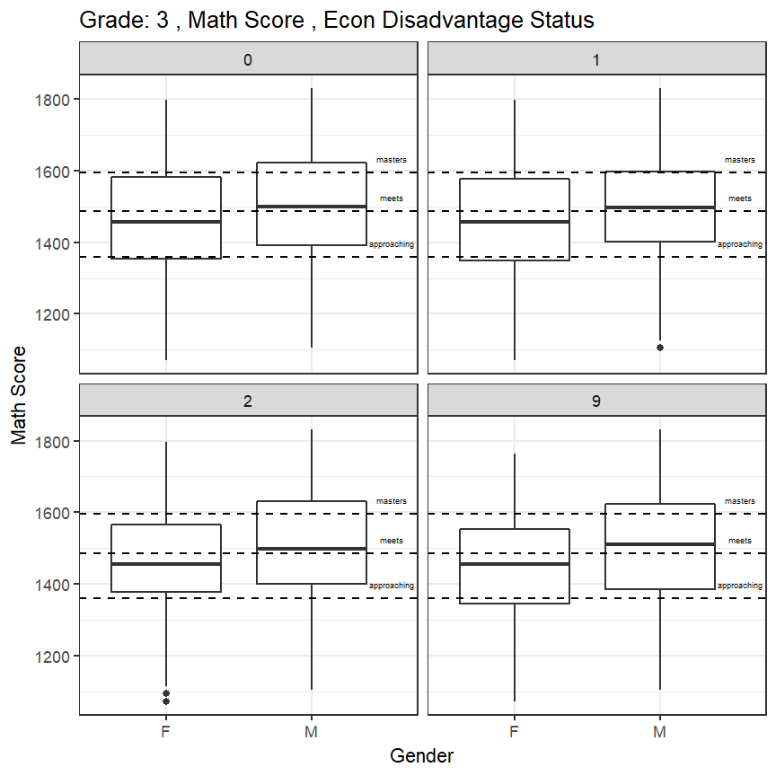

```r
# // Analysis 3: Comparing within groups--Socioeconomic gaps within our chosen features
# // Boxplots

#Loop over gap number in our table of gaps
for(i in 1:n.gaps){

  #Save grade, subject tested, and demographic information
  grade <- gaps[i,"grade_level"]
  subject <- gaps[i,"outcome"]
  dem <- gaps[i,"feature"]
  lvl1 <- gaps[i,"level_1"]
  lvl2 <- gaps[i,"level_2"]

  data = texas_data[texas_data$grade_level == grade,] #Isolates grade level
  data = data[data[,dem] == lvl1 | data[,dem] == lvl2, ]#Isolates demographic groups
  res <- levels(as.factor(data[,group.by])) #Different levels of 'group.by' to explore

  # Facet by group by
  bp <- ggplot(data, aes(x=as.factor(data[,dem]),
                               y=data[,subject])) +
              geom_boxplot() +
              ggtitle(paste("Grade:",grade,",",
                            labels[subject],",",labels[group.by])) +
              scale_y_continuous(name=labels[subject]) +
              scale_x_discrete(name=labels[dem]) + facet_wrap(group.by)

   #Add reference levels
   bp <- add_ref_levels(plot = bp, prof_levels = prof_lev, direction = "horizontal",
                         grade = grade, subject = subject) + theme_bw()

   print(bp) # Print boxplots

}# End loop over gap number
```

The box plots illustrate that the distributions are shifted upward for male students compared to female students across each socioeconomic marker. In addition, the magnitude of this shift appears consistent across quartiles, medians, minimums, and maximums. One particular trend the box plot reveals is that median scores for male students are consistently at the “meets standard” benchmark and above, whereas the median scores for female students fall below that benchmark in each group.

Since the summary tables already showed us that the medians between males and females tend to differ by about 40 for each group, and the histograms showed us that the shape of the distributions also remains roughly consistent across socioeconomic levels, we do not have reason to believe that gender inequities are very different between socioeconomic levels in our data. Since the gap persists at each socioeconomic level, our analysis should focus on the gender gap overall, rather than the gender gap for any one particular set of socioeconomic subgroups.

**Follow up question: How does this analysis look disaggregated by race/ethnicity?**

### Comparing gaps at schools

**Purpose:** When you already have a sense of which gaps are greatest in magnitude throughout the data set, it can be useful to pinpoint at which schools the gaps are most exaggerated (and at which schools the gaps are most narrow). Identifying these schools can lead to further investigation, providing context as to why these variations exist.

**Required Analysis File Variables:**

- `grade_level`
- `school_code`
- `male`
- `race_ethnicity`
- `math_ss`

**Ask Yourself**

- At what schools are the gaps most exaggerated? At what schools are the gaps most narrow?
- What further analyses could we perform to investigate the reasons behind variation in gap sizes between schools?

**Analytic Technique:** Calculate achievement gaps using standardized median differences within each school. We have decided to use medians, rather than means, because the distributions for our test scores (as shown in the histograms above) tend to be skewed left. With such skew, means can be deflated. Medians, which are less sensitive to skew, are often more effective measures of central tendency in such cases.

For this analysis we will standardize the assessment data before computing the median differences. The reason for doing this is to make the scale of the assessment easier to interpret. Instead of talking about scale score point differences, which vary with the grade level of the exam in most cases, we are talking about changes in scores relative to the mean. Standard deviation differences are helpful for evaluating the practical significance of differences - 99.7% of the data lies within 3 standard deviations of the mean, so a shift of 0.1 standard deviations can correspond to a large change in the relative position of a student group within the overall population.

Note: we standardize the median differences here by utilizing the state standard deviations on these exams (stored in `sd_table`). If these standard deviations are not available, as a stand-in, you can calculate the standard deviation within the data set you provide. There is commented out code within the chunk that you can activate to complete this task.

```
[1] "Gender ,difference of medians:  F - M"
[1] "Grade: 3 , Math Score"
   school_code median_diff
1            8  -0.6572479
2           10  -0.4756636
3            4  -0.4083432
4            6  -0.3257568
5            7  -0.3257568
6           11  -0.3187182
7           12  -0.3155889
8            9  -0.3082086
9     district  -0.2958738
10           2  -0.2250585
11           1  -0.1777400
12           5  -0.1554653
13           3  -0.1551231
```

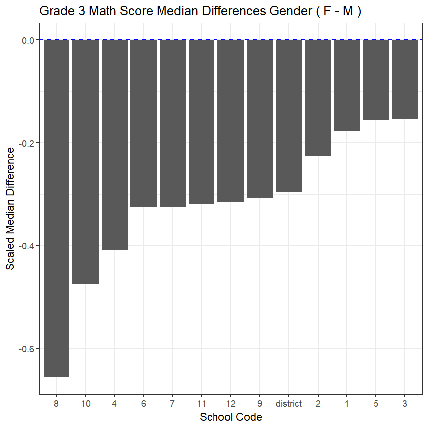

```r
# // Measure and sort standardized median differences by school
#Loop over gap number in our table of gaps
for(i in 1:n.gaps){

  #Save grade, subject tested, and demographic information
  grade <- gaps[i,"grade_level"]
  subject <- gaps[i,"outcome"]
  dem <- gaps[i,"feature"]
  lvl1 <- gaps[i,"level_1"]
  lvl2 <- gaps[i,"level_2"]

  data = texas_data[texas_data$grade_level == grade,] #Isolates grade level
  sd.within <- sd(data[,subject]) #Stores standard deviation for subject and grade level
  data = data[data[,dem] == lvl1 | data[,dem] == lvl2, ]#Isolates demographic groups

  #Finds overall district scaled median difference
  dis.meds <- tapply(data[,subject], data[,dem], median, na.rm=TRUE)
  dis.diff <- (dis.meds[lvl1] - dis.meds[lvl2])/
    sd_table[sd_table[,"grade_level"]==grade,subject]
  names(dis.diff) <- c("district")

  ##If no state standard deviation available, use this code instead,
  ##To find gaps and scales by by standard deviation
  #dis.meds <- tapply(data[,subject], data[,dem], median, na.rm=TRUE)
  #dis.diff <- (dis.meds[lvl1] - dis.meds[lvl2])/sd.within
  #names(dis.diff) <- c("district")

  #Finds medians by school and demographic marker
  school.meds <- tapply(data[,subject],
                        list(data$school_code, data[,dem]),
                        median, na.rm=TRUE)

  #Finds gaps and scales by standard deviation
  differences <- (school.meds[,lvl1] - school.meds[,lvl2])/
    sd_table[sd_table[,"grade_level"]==grade,subject]
  differences <- c(differences, dis.diff) #include district-wide difference

  ##If no state standard deviation available, use this code instead,
  ##To find gaps and scales by by standard deviation
  #differences <- (school.meds[,lvl1] - school.meds[,lvl2])/sd.within
  #differences <- c(differences, dis.diff) #include district-wide difference

  #Sorts the gaps, converts to dataframe, appends distrist median difference
  differences <- differences[order(differences)]
  med_diff_table <- data.frame(school_code = names(differences),
                                 median_diff = differences)
  rownames(med_diff_table) <- NULL

  #Prints table of differences
  print(paste(labels[dem], ",difference of medians: ",
              lvl1, "-",lvl2))
  print(paste("Grade:",grade,",",labels[subject]))
  print(med_diff_table)
  cat("\n\n")

  #Shows barplot of school median differences
  barp <- ggplot(med_diff_table, aes(x= reorder(school_code, median_diff),
                                     y=median_diff))+
                geom_bar(position="dodge",stat="identity")+
                scale_x_discrete(name = "School Code")+
                scale_y_continuous(name = "Scaled Median Difference")+
                ggtitle(paste("Grade",grade,labels[subject],
                              "Median Differences", labels[dem],
                              "(",lvl1,"-",lvl2,")")) +
    geom_hline(yintercept = 0, linetype = 2, color = "blue") + #ref line
    theme_bw()


  #Print barplot
  print(barp)

} # End loop over gap number
```

A common reaction to the above graphic is to wonder if the schools with the greatest magnitude gaps–such as school number 8 in our data–is discriminatory towards female students (in terms of math education). However, such a claim would require further analyses beyond the scope of this report.

First, it would be helpful to explore the size of each of these schools. Often, district data sets include small programs that are labeled with their own school codes. School 8 may be, for example, a program with only 20 students. With such a small sample size, an exaggerated gap could be due to noise in the data. We will look further into school size in the targeting analysis in the next section.

It is also helpful to take into account the unique dynamics of specialized schools. For example, school 8 may be a selective arts program, in which most of the students enrolled for performance art are female and most enrolled for music are male. In such a case, there may be a selection bias, as aspiring performance artists may focus on math less in their education than music students, who study rhythm and theory. Due to selection bias, this could show up in our analysis as a gender gap.

Ideally, we would want to look further into the practices and data of schools showing high gaps to identify root causes. Some additional pieces of evidence we could look, for example, would be the trajectory of the gap (is it widening or shrinking), participation rates in advanced mathematics courses by gender, or classroom observations of math instruction. These types of analyses would help further identify schools and provide additional information that schools could share about their practices and procedures to contrast high and low gap school practices. This visualization could provide impetus for the start a collaborative conversation between campuses.

### Identifying Target Schools

**Purpose:** Policymakers may propose interventions to work towards closing these gaps. Such interventions generally target the low-scoring student population and attempt to raise them up (through special programming, extra supports, or other methods) to the level of their counterparts. With limited resources, policymakers may have to choose which schools will immediately receive the intervention and which schools will not. The following analyses can be used to inform that decision.

**Required Analysis File Variables:**

- `grade_level`
- `school_code`
- `male`
- `race_ethnicity`
- `math_ss`

**Ask Yourself**

- Which is more important in this decision-making process: identifying the schools with the lowest median scores for a student population or identifying the campuses with the largest number of students (of our target population) performing below a certain benchmark?
- What types of interventions would be most useful for our target schools?

**Analytic Technique:** Calculate the median test scores at each campus among our target population (here, female students). This will give us a sense of where students from our target student population are performing relatively poorly compared to their peers at other schools. Again, we choose the medians here because they are less susceptible to skew and outliers. We will visualize these medians with bar charts, and we will visualize the three lowest performing schools with comparative box plots.

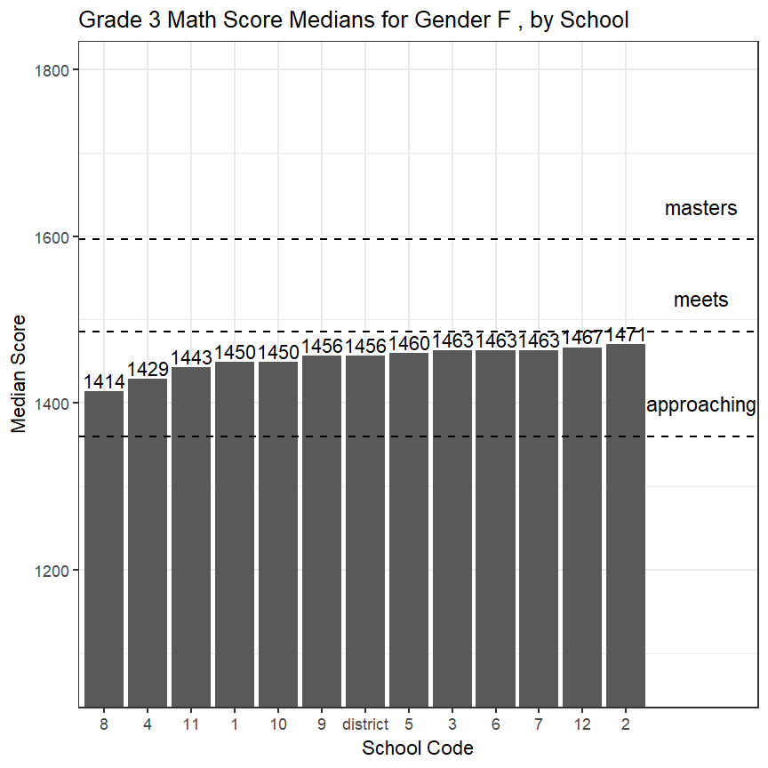

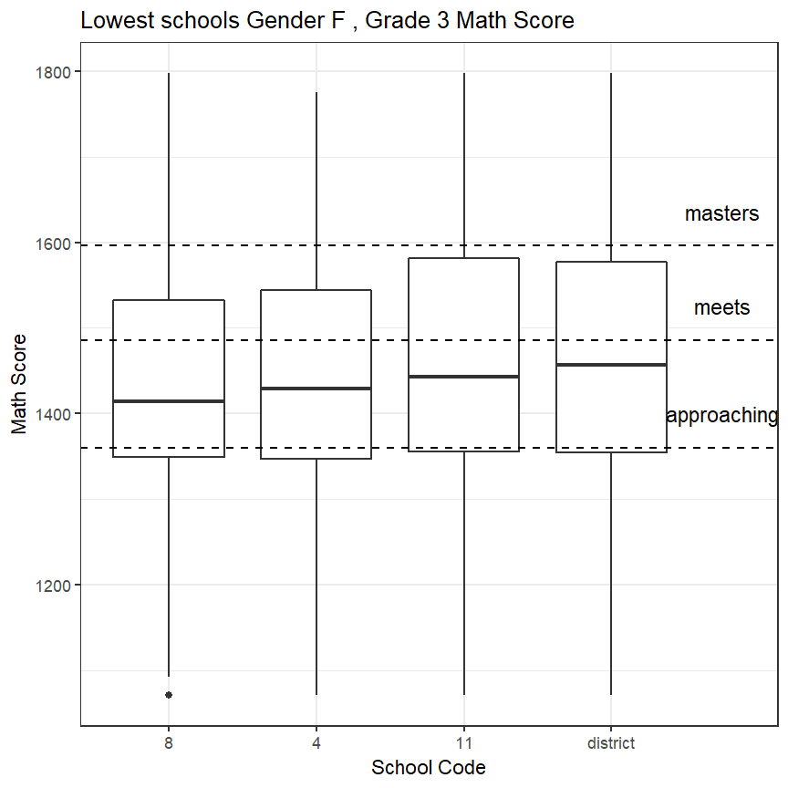

```r
# // Measure and sort medians by school
#Loop over gap number in our table of gaps
for(i in 1:n.gaps){

  #Save grade, subject tested, and demographic information
  grade <- gaps[i,"grade_level"]
  subject <- gaps[i,"outcome"]
  dem <- gaps[i,"feature"]

  #Isolates underperforming group in gap
  if(gaps[i,"effect_size"]>=0){

    #Target demographic is level 2 of comparison
    target <- gaps[i,"level_2"]

  }

  else{
    #Target demographic is level 1 of comparison
    target <- gaps[i,"level_1"]

  }#End of conditional

  data = texas_data[texas_data$grade_level == grade,] #Isolates grade level
  data = data[data[,dem] == target, ]#Isolates target demographic

  #Finds overall district median
  dis.med <- median(data[,subject])
  names(dis.med) <- c("district")

  #Finds medians by school and demographic marker
  school.meds <- tapply(data[,subject],
                        data$school_code,
                        median, na.rm=TRUE)
  school.meds <- c(school.meds, dis.med) #include district-wide median

  #Sorts the medians (smallest to largest), converts to dataframe
  school.meds <- school.meds[order(school.meds)]
  med_table <- data.frame(school_code = names(school.meds),
                                 median = school.meds)
  rownames(med_table) <- NULL

  #Set y-axis limits for bar plot
  lim1 <- min(data[,subject])
  lim2 <- max(data[,subject])

  #Shows barplot of school medians
  barp <- ggplot(med_table, aes(x= reorder(school_code, median), y=median)) +
                geom_bar(stat="identity")+
                geom_text(aes(label=round(median)), vjust=-0.25)+
                scale_x_discrete(name = "School Code")+
                scale_y_continuous(name = "Median Score")+
                coord_cartesian(ylim=c(lim1,lim2))+
                ggtitle(paste("Grade",grade,labels[subject],
                              "Medians for", labels[dem],target,
                              ", by School"))
  barp <- add_ref_levels(plot = barp, prof_levels = prof_lev, direction = "horizontal",
                         grade = grade, subject = subject) + theme_bw()
  print(barp)

  #Isolate data for lowest 3 schools
  low.schools <- as.character(med_table[1:3,"school_code"])
  data$school_code <- as.character(data$school_code)
  data.low <- subset(data, school_code == low.schools[1] |
                       school_code == low.schools[2] |
                       school_code == low.schools[3])
  data.low$school_code <- factor(data.low$school_code,
                                 levels = low.schools,ordered=TRUE)

  #Show box plots of 3 lowest schools and district overall
  boxp <- ggplot(data.low, aes(x=school_code , y=data.low[,subject])) +
                geom_boxplot() +
                geom_boxplot(data=data, aes(x = factor("district"), y = data[,subject]))+
                scale_x_discrete(limits = c(low.schools,"district"),
                                 name="School Code")+
                scale_y_continuous(name=labels[subject])+
                ggtitle(paste("Lowest schools",labels[dem],
                              target,", Grade",grade,labels[subject]))
  boxp <- add_ref_levels(plot = boxp, prof_levels = prof_lev, direction = "horizontal",
                         grade = grade, subject = subject) + theme_bw()

  print(boxp)

} # End loop over gap number
```

Here we see that schools 8 and 4, which had among the three widest gaps, also had median math scores for female students that were among the lowest in the district. By contrast, school 11 had a relatively moderate gender gap within the school, even though it also had a median math score among the three lowest overall. This may mean that school 11’s male students also perform relatively poorly on math exams, making the gap within the school less pronounced.

Given that districts have limited resources, it may also be useful to take school size into account. For example, a small school may have the worst median female student performance in a district. However, it could be more efficient to target a larger school with slightly higher median performance scores if that school has more low-scoring female students overall. At the larger school, in theory, a new intervention effort could reach a greater number of low-scoring female students than at the smaller school. Therefore, it could more effectively contribute to the closing of the district achievement gap overall.

We model this type of analysis below. Of course, if this technique is used in isolation, it has the potential downside of systematically preferencing resources towards larger schools. The result could be perceived favoritism or discrimination. Therefore, this analysis should provide just one among several considerations when picking target schools.

**Analytic Technique:** Isolate the raw number of students at each school in our target populations who perform below certain benchmarks. We will do this in two ways:

1. We will look at the number of target students in each campus who scored below the district-wide median.
2. We will look at the number of target students at each campus who scored below the district-wide first quartile.

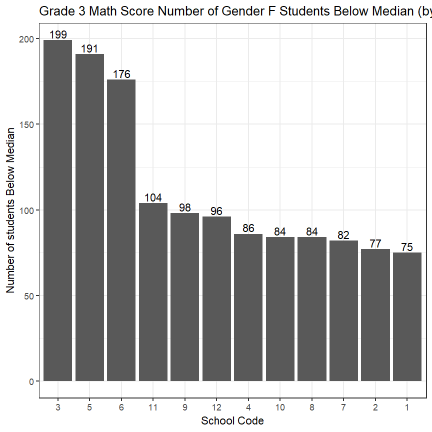

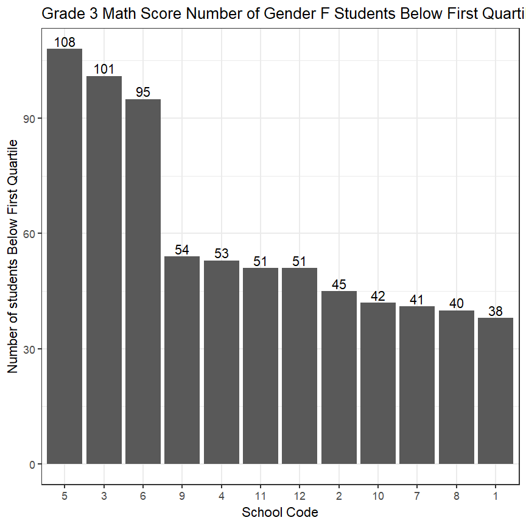

```r
## // Find number of low-scoring students by school
#Loop over gap number in our table of gaps
for(i in 1:n.gaps){

  #Save grade, subject tested, and demographic information
  grade <- gaps[i,"grade_level"]
  subject <- gaps[i,"outcome"]
  dem <- gaps[i,"feature"]

  #Isolates underperforming group in gap
  if(gaps[i,"effect_size"]>=0){

    #Target demographic is level 2 of comparison
    target <- gaps[i,"level_2"]

  }

  else{

    #Target demographic is level 1 of comparison
    target <- gaps[i,"level_1"]

  }#End of conditional

  #Isolates grade level
  data = texas_data[texas_data$grade_level == grade,]

  #Calculates district median and first quartile scores for test
  dist.median <- median(data[,subject]) #district median
  dist.quant <- quantile(data[,subject])[["25%"]] #district first quartile

  #Isolates target demographic
  data = data[data[,dem] == target, ]#Isolates target demographi
  data$below_med <- data[,subject] < dist.median #Adds indicator if below median
  data$below_quant <- data[,subject] < dist.quant #Adds indicator if below first quartile

  #Initialize vectors for a loop to get numbers below median and quartile and plot them
  cuts <- c("below_med","below_quant")
  cut.labels <- c("Below Median","Below First Quartile")
  names(cut.labels) <- cuts

  #Loop over median and quartile analysis
  for(cut in cuts){

    #Finds number of students at each school below cut
    school.data <- tapply(data[,cut],
                        data$school_code,
                        sum, na.rm=TRUE)
    school.data <- school.data[order(school.data, decreasing=TRUE)] #sort descending order
    school_table <- data.frame(school_code = names(school.data), #make into table
                                   count = school.data)
    rownames(school_table) <- NULL

    #Shows barplot of number below cut by school
    barp <- ggplot(school_table, aes(x= reorder(school_code, -count), y=count)) +
                geom_bar(stat="identity")+
                geom_text(aes(label=count, vjust=-0.25))+
                scale_x_discrete(name = "School Code")+
                scale_y_continuous(name = paste("Number of students",cut.labels[cut]))+
                ggtitle(paste("Grade",grade,labels[subject],
                              "Number of", labels[dem],target,
                              "Students",cut.labels[cut],
                              "(by School)")) + theme_bw()

    print(barp)

  } #End loop over cuts

} # End loop over gap number
```

From this visualization, we see that interventions would reach the greatest number of low-scoring students in our targeted population if implemented at schools 3, 5, and 6. The schools that seemed like likely targets from our previous analyses–schools 8, 4, and 11–have fewer low-scoring female students.

In making a final selection of schools for intervention, policymakers would have to weigh the goal of minimizing the achievement gap in the district overall against the potential downside of biasing the placement of interventions towards larger schools.

### Isolating effects of covariates

**Purpose:** Students possess many individual and demographic features that simultaneously affect their education. It can be hard to determine, from an equity perspective, what factor most affects a student’s ability to learn and achieve.

For example, in the data, you may notice migrant students generally score lower on reading tests. One could draw the conclusion from this trend that there exist direct barriers to achievement for migrant students that the district or state must tackle.

However, many migrant students may be Limited English Proficient (LEP) learners. In many cases, LEP students in general also have lower reading scores, due to language barriers. Can the correlation between migrant status and lower scores be mostly explained by such language barriers? Or does the noticeable score effect from migrant status remain, even when we control for English proficiency level? Testing out this nuance, and others like it, can help a district hone its efforts and create better policy for low-scoring student populations.

**Required Analysis File Variables:**

- `grade_level`
- `school_code`
- `male`
- `race_ethnicity`
- `eco_dis`
- `lep`
- `math_ss`

**Ask Yourself**

- Can we draw causal estimates from this type of analysis, or is it only correlational?
- How do we best choose what controls we use in our equations?

**Analytic Technique:** Perform multiple regression. We choose multiple regression because our outcome variable (scale scores on tests) is approximately continuous, and the technique will allow us to come up with our correlation estimates while controlling for various factors. Note: the user will have to set the variable for which s/he would like to control. Many combinations are possible, and we make the following specific recommendations (the code will default to these recommendations):

- If analyzing race gaps, control for socioeconomic level and English proficiency status.
- If analyzing gender gaps, control for race and socioeconomic level.
- If analyzing socioeconomic gaps, control for race and English proficiency status.

In the code block below, there is space to override these defaults if you would like to control for other factors in combinations other than the ones listed above. Note that this code is largely based on similar analyses from OpenSDP’s college-going analyses. An example college-going guide can be found [here](https://opensdp.github.io/college-going-r/college_going_enrollment.html) (along with its accompanying repository [here](https://github.com/opensdp/college-going-r)).

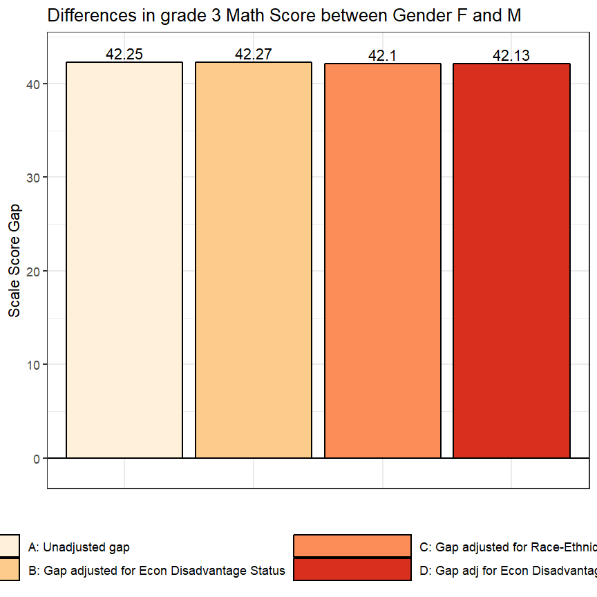

```r
# // Step 1: Initialize controls
control.1 <- "eco_dis"
control.2 <- "race_ethnicity"

#Loop over gap number in our table of gaps
for(i in 1:n.gaps){

  #Save grade, subject tested, and demographic information
  grade <- gaps[i,"grade_level"]
  subject <- gaps[i,"outcome"]
  dem <- gaps[i,"feature"]

  #Conditional to set default controls for race analysis
  if(dem == "race_ethnicity"){

    control.1 <- "eco_dis"
    control.2 <- "lep"

  }#End conditional

  #Conditional to set default controls for gender analysis
  if(dem == "male"){

    control.1 <- "eco_dis"
    control.2 <- "race_ethnicity"

  }#End conditional

  #Conditional to set default controls for SES analysis
  if(dem == "eco_dis"){

    control.1 <- "race_ethnicity"
    control.2 <- "lep"

  }#End conditional

  ##OVERRIDE: Set controls here to override defaults
  #control.1 <- "iep"
  #control.2 <- "migrant"

  #Isolates high performing group in gap
  if(gaps[i,"effect_size"]>=0){

    #Reference demographic is level 1 of comparison, target is level 2
    ref.group <- gaps[i,"level_1"]
    target <- gaps[i,"level_2"]

  }

  else{

    #Reference demographic is level 2 of comparison, target is level 1
    ref.group <- gaps[i,"level_2"]
    target <- gaps[i,"level_1"]

  }#End of conditional

  # // Step 2: Isolate grade level
  data = texas_data[texas_data$grade_level == grade,] #Isolates grade level

  # // Step 3: Recode variables and create cluster variable
  data[,dem] <- as.factor(data[,dem])
  data[,dem] <- relevel(data[,dem], ref = ref.group)

  # // Step 4: Create a unique identifier for clustering standard errors
  # at the school level
  data$cluster_var <- data$school_code

  # Load the broom library to make working with model coefficients simple
  # and uniform
  library(broom)

  # // Step 5: Estimate the unadjusted and adjusted gaps

  # Estimate unadjusted enrollment gap
  #  Fit the model
  mod1 <- lm(data[,subject] ~ data[,dem])
  #  Extract the coefficients
  betas_unadj <- tidy(mod1)
  #  Get the clustered variance-covariance matrix
  #  Use the get_CL_vcov function from the functions.R script
  clusterSE <- get_CL_vcov(mod1, data$cluster_var)
  #  Get the clustered standard errors and combine with the betas
  betas_unadj$std.error <- sqrt(diag(clusterSE))
  betas_unadj <- betas_unadj[, 1:3]
  #  Label
  betas_unadj$model <- "A: Unadjusted gap"

  # Estimate score gap adjusting for first control
  mod2 <- lm(data[,subject] ~ data[,dem] + data[,control.1])
  betas_adj_control_1 <- tidy(mod2)
  clusterSE <- get_CL_vcov(mod2, data$cluster_var)
  betas_adj_control_1$std.error <- sqrt(diag(clusterSE))
  betas_adj_control_1 <- betas_adj_control_1[, 1:3]
  betas_adj_control_1$model <- paste("B: Gap adjusted for", labels[control.1])

  # Estimate score gap adjusting for second control
  mod3 <- lm(data[,subject] ~ data[,dem] + data[,control.2])
  betas_adj_control_2 <- tidy(mod3)
  clusterSE <- get_CL_vcov(mod3, data$cluster_var)
  betas_adj_control_2$std.error <- sqrt(diag(clusterSE))
  betas_adj_control_2 <- betas_adj_control_2[, 1:3]
  betas_adj_control_2$model <- paste("C: Gap adjusted for", labels[control.2])

  # Estimate score gap adjusting for both controls
  mod4 <- lm(data[,subject] ~ data[,dem] + data[,control.1] + data[,control.2])
  betas_adj_all <- tidy(mod4)
  clusterSE <- get_CL_vcov(mod4, data$cluster_var)
  betas_adj_all$std.error <- sqrt(diag(clusterSE))
  betas_adj_all <- betas_adj_all[, 1:3]
  betas_adj_all$model <-  paste("D: Gap adj for",
                                labels[control.1],"&",labels[control.2])

  # // Step 6. Transform the regression coefficients to a data object for plotting
  chartData <- bind_rows(betas_unadj, betas_adj_control_1, betas_adj_control_2,
                      betas_adj_all)

  # // Step 7. Plot

  #Set y-axis limits
  lim2 <- -(min(chartData[chartData$term == paste("data[, dem]",target,sep=""),"estimate"])-1)
  lim1 <- -(max(chartData[chartData$term == paste("data[, dem]",target,sep=""), "estimate"])+1)

  if(lim2 > 0 & lim1 > 0){

    lim1 <- -1
  }

  if(lim2 < 0 & lim1 < 0){

    lim2 <- 1
  }

  chartData$estimate_lab <- round(chartData$estimate, digits = 2)

  #Make barplot
  b <- ggplot(chartData[chartData$term == paste("data[, dem]",target,sep=""), ],
         aes(x = model, y = -estimate, fill = model)) +
          geom_bar(stat = 'identity', color = I("black")) +
          scale_fill_brewer(type = "seq", palette = 8) +
          geom_hline(yintercept = 0) +
          guides(fill = guide_legend("", keywidth = 6, nrow = 2)) +
          geom_text(aes(label = -estimate_lab, vjust = -0.3)) +
          scale_y_continuous(limit = c(lim1,lim2), name = "Scale Score Gap") +
          labs(title = paste("Differences in grade",grade,labels[subject],
                             "between",labels[dem],target,"and",ref.group),
               x = "") + theme_bw() +
    theme(legend.position = "bottom", axis.text.x = element_blank(),
                                  axis.ticks.x = element_blank())
  #Print
  print(b)

}#End loop over gap number
```

The gender gap, as demonstrated by the regression coefficient values visualized as bars above, remains highly consistent, even after controlling for race-ethnicity and economic disadvantage level in our data set. In the regression equations, the coefficient remains highly significant (p < 0.0001). Therefore, we know that the gap cannot be explained by variation due to race or economic disadvantage level.

This trend was partially shown earlier in our analysis, as the gaps and shapes of the math score distributions for gender were consistent across socioeconomic levels.